# standard-analysis-tutorial

```r
library(standardanalysis)
```

# Microbiome data analysis in R

```r
input_directory <- "C:/GitHub/ACTA-Preventive-Dentistry/standard-16s-analysis/data/"
biom_file_name <- "test_biom_water.biom"
mapping_file_name <- "test_mapping_file.txt"
treatment_variable <- "Source"

#setwd(input_directory)
```

## Input data

#### Import the BIOM and mapping file.

```r
ps <- import_data(biom_file_name, mapping_file_name)
```

```
#> Time to complete depends on OTU file size
```

```r
# Function for clean-up taxonomy
ps <- clean_taxonomy(ps)
```

## Normalizing the library sizes (Rarefying)

```r
read_num <- phyloseq::sample_sums(ps)
print(sort(read_num))
```

```
#> MB.30.NP.0.MB.DNA055 MB.30.NP.0.MB.DNA054 MB.30.NP.0.MB.DNA053
#>                23719                26919                27161
#> MB.30.NP.0.MB.DNA051  MB.30.P.0.MB.DNA063 MB.30.NP.0.MB.DNA050
#>                30676                31120                32720
#> MB.30.NP.0.MB.DNA049 MB.30.NP.0.MB.DNA056  MB.30.P.0.MB.DNA060
#>                32982                35594                35712
#>  MB.30.P.0.MB.DNA057  MB.30.P.0.MB.DNA059 MB.30.NP.0.MB.DNA052
#>                36524                37539                37995
#>  MB.30.P.0.MB.DNA062  MB.30.P.0.MB.DNA061  MB.30.P.0.MB.DNA064
#>                39511                40272                42120
#>  MB.30.P.0.MB.DNA058
#>                42231
```

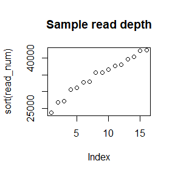

```r
plot(sort(read_num), main = "Sample read depth")
```

## Plotting rarecurve

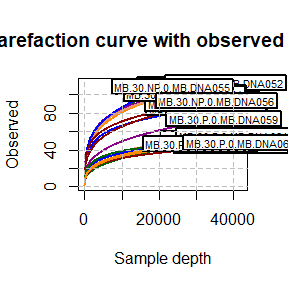

```r
rare_curve(ps, label = T)
```

## Removing unwanted sample(s)

```r
unwanted_samples <- c("MB.30.NP.0.MB.DNA048") # replace with your own sample names
ps <- phyloseq::subset_samples(ps, !X.SampleID %in% unwanted_samples)

# Check if the right ones are removed
microbiome::meta(ps)$X.SampleID
```

```
#>  [1] "MB.30.NP.0.MB.DNA049" "MB.30.NP.0.MB.DNA050" "MB.30.NP.0.MB.DNA051"
#>  [4] "MB.30.NP.0.MB.DNA052" "MB.30.NP.0.MB.DNA053" "MB.30.NP.0.MB.DNA054"
#>  [7] "MB.30.NP.0.MB.DNA055" "MB.30.NP.0.MB.DNA056" "MB.30.P.0.MB.DNA057"
#> [10] "MB.30.P.0.MB.DNA058"  "MB.30.P.0.MB.DNA059"  "MB.30.P.0.MB.DNA060"
#> [13] "MB.30.P.0.MB.DNA061"  "MB.30.P.0.MB.DNA062"  "MB.30.P.0.MB.DNA063"
#> [16] "MB.30.P.0.MB.DNA064"
```

## Rarefaction of samples

```r
ps_rare <- rarefy(ps, depth = 0, mc = 1000)
```

```
#> [1] "You chose not to rarefy. Samples with less than mc will be removed."
```

## Calculating the diversity and plotting samples.

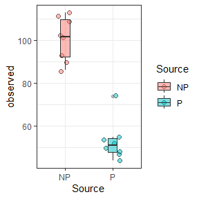

```r
alpha_boxplot(ps_rare, x_grp = treatment_variable, a_index = "observed", na.rm = T)
```

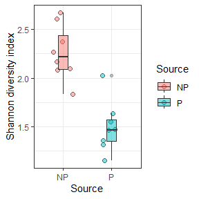

```r
alpha_boxplot(ps_rare, x_grp = treatment_variable, a_index = "diversity_shannon") +
  ggplot2::ylab("Shannon diversity index")
```

## Multiple rarefaction

As an alternative to rarefying a phyloseq object once, here, we will perform rarefaction over multiple phyloseq objects. The idea is that it should give us an estimate of the variance in rarefied phyloseq objects that we would not be able to see from a single rarefied phyloseq object.

### Making a list of rarefied phyloseq objects

You can choose your sample size for rarefaction and the amount of rarefied phyloseq objects that you want to create.

```r
ps_list <- rarefy_multiple(ps, sample.size = 2000, iter = 10)
```

### Diversity testing with multiple rarefaction

Now we can test diversity over all the rarefied phyloseq objects. Alpha-diversity is calculated, in this case Shannon-diversity. In the first function you should also already declare your variable wherein you want to compare diversities, “Source” in the example. The median values will then be calculated for each sample and these will be added as a column in the original phyloseq object meta-data.

```r
alpha_df <- calculate_alpha_df(ps_list, measures = c("Shannon", "Simpson", "Chao1"))

ps_multi_ss <- phyloseq::subset_samples(ps, microbiome::meta(ps)$X.SampleID %in% unique(alpha_df$X.SampleID))
phyloseq::sample_data(ps_multi_ss) <- cbind(phyloseq::sample_data(ps_multi_ss), calculate_average_alpha_ps(alpha_df))
```

### Plotting diversity for multiple rarefaction

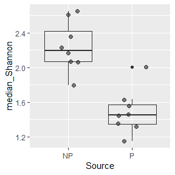

```r
microbiome::boxplot_abundance(ps_multi_ss, x = treatment_variable, y = "median_Shannon")
```

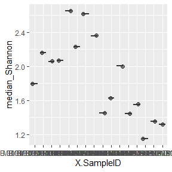

```r
microbiome::boxplot_abundance(ps_multi_ss, x = "X.SampleID", y = "median_Shannon")
```

```r
# Note that you dont use average values here but "raw" alpha-div
multiple_test_alpha(
  alpha_df,
  pseq = ps_multi_ss,
  alpha_div = "Shannon",
  variable = treatment_variable,
  method = "wilcox.test"
)
```

```
#>  [1] 0.0003108003 0.0003108003 0.0003108003 0.0003108003 0.0003108003
#>  [6] 0.0003108003 0.0003108003 0.0003108003 0.0003108003 0.0003108003
```

```r
# median(x), mean(X), summary(x), min(x) (minimum)
# For example - using the above:
# median(multiple_test_alpha(alpha_df, ps, "Source", method = "t.test"))
```

### PERMANOVA for multiple phyloseq objects

```r
adonis_results <- multiple_permanova(
  ps_list,
  distance = "bray",
  variable = "Readdepth + DNA_Conc",
  permutations = 999,
  longit = "Source"
)
permanova_p_average(adonis_results, averagef = "max")
```

```
#>    Variable max P-value
#> 1 Readdepth       0.694
#> 2  DNA_Conc       0.116
```

## Plotting abundance graph

[figure not shown]

```r
# https://microbiome.github.io/tutorials/Composition.html
# Give taxonomic level, detection, prevalence.

# Optional to split plot by a variable: use "group_by = treatment_variable

# For grouping more than two variables, use outside of the function:
# + facet_wrap(Var1~Var2, scales = "free_x")
# or alternatively for nested-groups
# + facet_wrap(~Var1 + Var2, scales = "free_x")

barplot_abundance(
  ps,
  level = "Family",
  detection = 5 / 100,
  prevalence = 0 / nrow(microbiome::meta(ps))
) #+ facet_wrap(~My_grouping_variable + My_other_grouping_variable, scales = "free_x")
```

## Performing a PCA, and making of ordination plot.

Samples are coloured by treatment variable, default transformation is center log ratio (CLR). Pseudo-count (shift) is + 1 for all log-transformations

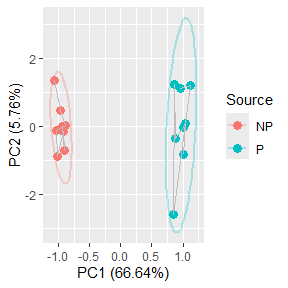

```r
# Optional to also give a different shape to points based on a variable: shape = "My_other_variable"
make_pca(ps,
         colour_by = treatment_variable,
         ellipse = T,
         longi_lines = "Source"
         )
```

## Heatmap

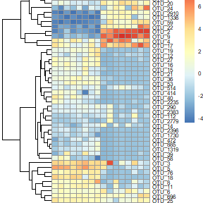

```r
make_heatmap(ps,
             detection = 7,
             prevalence = 0.4)
```

```r
# If this plot is too big to be shown properly, you can try copying the line with 'heatmap_make(...)' and paste it in the console-window down below this window.
# Do play around with the detection and prevalence, these defaults are just values that worked with the test data: detection = 7, prevalence = 0.4
```

## PERMANOVA

### Unpaired / independent

The following is a PERMANOVA for unpaired or independent samples. You can subset as follows (for example): > ps_subset_sick65 <- subset_samples(ps, HealthStatus == “Sick” & age > 65)

Remember that subsetting decreases your sample size. In case you want to transform your data (i.e. CLR), now is a good time for that. Here I use a pseudocount of 1.

```r
ps_shift <- microbiome::transform(ps, transform = "shift", shift = 1)
ps_clr <- microbiome::transform(ps_shift, transform = "clr")


vegan::adonis2(as.formula(paste("phyloseq::distance(phyloseq::otu_table(ps_clr), method = 'euclidean') ~",
                         treatment_variable)),
       data = microbiome::meta(ps_clr),
       permutations = 9999)
```

```
#> Permutation test for adonis under reduced model
#> Terms added sequentially (first to last)
#> Permutation: free
#> Number of permutations: 9999
#>
#> vegan::adonis2(formula = as.formula(paste("phyloseq::distance(phyloseq::otu_table(ps_clr), method = 'euclidean') ~", treatment_variable)), data = microbiome::meta(ps_clr), permutations = 9999)
#>          Df SumOfSqs      R2      F Pr(>F)
#> Source    1   3581.8 0.66247 27.478  2e-04 ***
#> Residual 14   1824.9 0.33753
#> Total    15   5406.7 1.00000
#> ---
#> Signif. codes:  0 '***' 0.001 '**' 0.01 '*' 0.05 '.' 0.1 ' ' 1
```

### Paired / longitudinal

In case you want to perform paired PERMANOVA, you have to assign the variable wherein you want to restrict permutations. This can be something like PatientID, Sample_location etc. Note that if it says in the output “permutation: free”, something went wrong and you did not actually restrict the permutations.

```r
ps_shift <- microbiome::transform(ps, transform = "shift", shift = 1)
ps_clr <- microbiome::transform(ps_shift, transform = "clr")

longitudinal_variable <- ""

perm <- permute::how(nperm = 9999)
dat <- microbiome::meta(ps_clr)
permute::setBlocks(perm) <- with(dat, microbiome::meta(ps_clr)[[longitudinal_variable]])

vegan::adonis2(as.formula(paste("phyloseq::distance(phyloseq::otu_table(ps_clr), method='euclidean') ~",
                         treatment_variable)),
       data = dat,
       permutations = perm)
```

```
#> Permutation test for adonis under reduced model
#> Terms added sequentially (first to last)
#> Permutation: free
#> Number of permutations: 9999
#>
#> vegan::adonis2(formula = as.formula(paste("phyloseq::distance(phyloseq::otu_table(ps_clr), method='euclidean') ~", treatment_variable)), data = dat, permutations = perm)
#>          Df SumOfSqs      R2      F Pr(>F)
#> Source    1   3581.8 0.66247 27.478  2e-04 ***
#> Residual 14   1824.9 0.33753
#> Total    15   5406.7 1.00000
#> ---
#> Signif. codes:  0 '***' 0.001 '**' 0.01 '*' 0.05 '.' 0.1 ' ' 1
```

## Differential abundance analysis

# ALDEx2

The ALDEx2 authors recommend 128 or more mc.samples for the t-test, 1000 for a rigorous effect size calculation, and at least 16 for ANOVA. Try a low amount (16) first and then later change if it runs like it should. Effect size confidence interval: The authors find that the SAFEST approach is to identify those features that where the 95% CI of the effect size does not cross 0. As for effect size threshold, in the ALDEx2 vignettes paragraph 5.3 the authors state the following: “We suggest that an effect size cutoff of 1 or greater be used when analyzing HTS datasets. If preferred the user can also set a fold-change cutoff as is commonly done with P value based methods.” For the ALDEx2 results, see the vignette: https://www.bioconductor.org/packages/devel/bioc/vignettes/ALDEx2/inst/doc/ALDEx2_vignette.html

```r
# Calculating instances and clr transform
x <- ALDEx2::aldex.clr(as.data.frame(phyloseq::otu_table(ps)),
               microbiome::meta(ps)[[treatment_variable]],
               mc.samples = 128,
               denom = "all",
               verbose = TRUE)

# Testing
x.tt <- ALDEx2::aldex.ttest(x,
                    paired.test = FALSE,
                    verbose = FALSE)
x.effect <- ALDEx2::aldex.effect(x,
                         CI = TRUE,
                         verbose = FALSE,
                         paired.test = FALSE)

# Plotting
x.all <- data.frame(x.tt,x.effect)
par(mfrow = c(1,2))
ALDEx2::aldex.plot(x.all, type = "MA", all.pch=19, all.cex=0.4,
    called.col = "red", called.pch=20, called.cex=0.6,
    thres.line.col= "darkgrey", thres.lwd=1.5,
    test = "welch", rare.col = "black",
    rare = 0, rare.pch=20, rare.cex=0.2 )
ALDEx2::aldex.plot(x.all, type = "MW", test = "welch")

# Effect interval does not cross 0, has effect > 1 (or -1), has significant test with error correction
x.all_sign <- subset(x.all, (x.all$effect.low > 0 & x.all$effect.high > 0) |
                      (x.all$effect.low < 0 & x.all$effect.high < 0) |
                        abs(x.all$effect) > 1 |
                        x.all$wi.eBH <= 0.05)

# I will print only the columns that are more interesting
x.all_int <- x.all_sign[-c(1,2,5:9,13)]

# Sorting on effect size
print(x.all_int[order(abs(x.all_int$effect), decreasing = TRUE),])
```

[output not shown]

# ANCOM2

```r
out <- ANCOMBC::ancombc2(
  data = ps,
  fix_formula = treatment_variable)
res_anc <- out$res

# Select columns with significance after correction
res_anc_clean <- subset(res_anc, res_anc[,11] <= 0.05)

# Only show relevant columns
res_anc_int <- res_anc_clean[-c(2:8,10,12,13)]
print(res_anc_int[order(res_anc_int[,3], decreasing = FALSE), ])
```

[output not shown]

# Maaslin2

```r
# For both the asv/otu table as well as meta data
otu <- t(phyloseq::otu_table(ps))
meta_data <- data.frame(microbiome::meta(ps))

# You can specifiy different GLMs/normalizations/transforms. These are according to  Nearing 2021 settings.
fit_data <- Maaslin2::Maaslin2(
  otu,
  meta_data,
  output = "My_maaslin2_analysis",
  transform = "AST",
  fixed_effects = treatment_variable,
  normalization = "TSS",
)

res_ms2 <- fit_data$results
res_ms2_clean <- subset(res_ms2, res_ms2$qval <= 0.05)
res_ms2_int <- res_ms2_clean[-c(2,3,5,7,9,10)]
print(res_ms2_int)
```

[output not shown]

# Intersection of OTUs found differentially abundant by all three methods

```r
sign_aldex <- rownames(x.all_int)
sign_ancom <- res_anc_int[,1]
sign_maaslin2 <- res_ms2_int[,1]

sign_3 <- intersect(sign_aldex, intersect(sign_ancom, sign_maaslin2))
as.data.frame(tax_table(ps)[sign_3, -c(1:4)])
```

[output not shown]